# Дискриминантный анализ

Агеев Владимир

2 декабря 2016 г.

# Данные и проверка модели

## Данные

Wholesale customers Data Set (“Потребители оптовика”)

Данные об оптовых продажах за год в Португалии.

1. FRESH: годовые затраты (у.е.) на свежие продукты (Continuous);
2. MILK: годовые затраты (у.е.) на молочные продукты (Continuous);
3. GROCERY: годовые затраты (у.е.)on grocery products (Continuous);
4. FROZEN: годовые затраты (у.е.) на замороженные продукты (Continuous)
5. DETERGENTS_PAPER: годовые затраты (у.е.) на бытовую химию и бумажную продукцию (Continuous)
6. DELICATESSEN: годовые затраты (у.е.) на деликатесы (Continuous);
7. CHANNEL: канал сбыта - отели/рестораны или розница (Nominal) (1, 2)
8. REGION: регион сбыта - Лиссабон, Порту или другие города (Nominal) (1, 2, 3)

```r
sales.data <- read.csv2("Wholesale.csv", sep = ",")
head(sales.data)
```

```
##   Channel Region Fresh Milk Grocery Frozen Detergents_Paper Delicassen
## 1       2      3 12669 9656    7561    214             2674       1338
## 2       2      3  7057 9810    9568   1762             3293       1776
## 3       2      3  6353 8808    7684   2405             3516       7844
## 4       1      3 13265 1196    4221   6404              507       1788
## 5       2      3 22615 5410    7198   3915             1777       5185
## 6       2      3  9413 8259    5126    666             1795       1451
```

Смешаем признаки, чтобы было интереснее смотреть на значимое число дискриминантных функций.

```r
sales.data$Channel <- as.factor(sales.data$Channel)
sales.data$Region <- as.factor(sales.data$Region)
sales.data$ChannelAndRegion <- with(sales.data, interaction(Channel, Region))

levels(sales.data$Channel)
```

```
## [1] "1" "2"
```

```r
levels(sales.data$Region)
```

```
## [1] "1" "2" "3"
```

```r
levels(sales.data$ChannelAndRegion)
```

```
## [1] "1.1" "2.1" "1.2" "2.2" "1.3" "2.3"
```

Цвета для matrixplot’а.

```r
nums <- c("Fresh","Milk","Grocery","Frozen","Detergents_Paper","Delicassen")
factor.colors <- palette(c(rgb(134,82,187, maxColorValue=255),
    rgb(148,195,92, maxColorValue=255),
    rgb(189,85,126, maxColorValue=255),
    rgb(146,180,183, maxColorValue=255),
    rgb(196,112,62, maxColorValue=255),
    rgb(75,64,63, maxColorValue=255)))
```

Колчичество индивидов по группам.

```r
sapply(levels(sales.data$ChannelAndRegion), function(level){
  nrow(sales.data[sales.data$ChannelAndRegion == level,])
})
```

```
## 1.1 2.1 1.2 2.2 1.3 2.3
##  59  18  28  19 211 105
```

Matrixplot.

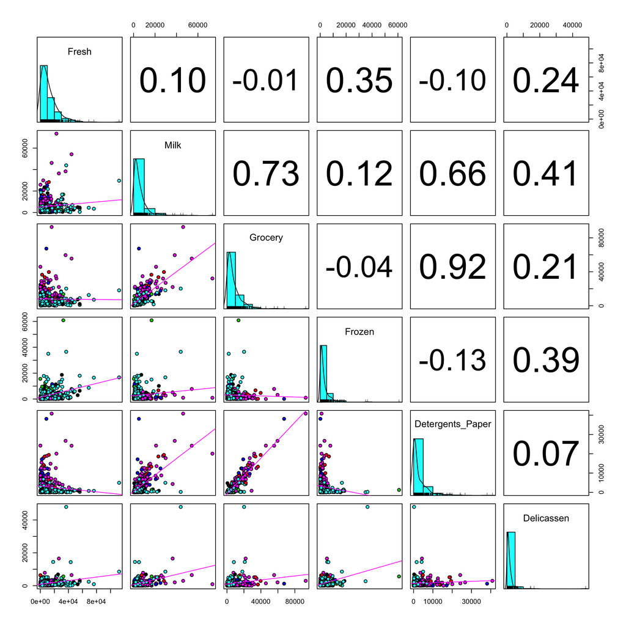

```r
pairs.panels(sales.data[,nums],
               bg=factor.colors[sales.data$ChannelAndRegion],
               col=factor.colors[sales.data$ChannelAndRegion],
               pch=21,
               lm=TRUE,
               lwd = 1,
               ellipses = FALSE)
```

Прологорифмируем все.

```r
sales.data.log <- sales.data
sales.data.log$Fresh <- log(sales.data.log$Fresh)
sales.data.log$Milk <- log(sales.data.log$Milk)
sales.data.log$Grocery <- log(sales.data.log$Grocery)
sales.data.log$Frozen <- log(sales.data.log$Frozen)
sales.data.log$Detergents_Paper <- log(sales.data.log$Detergents_Paper)
sales.data.log$Delicassen <- log(sales.data.log$Delicassen)
sales.data.log.ch <- sales.data.log[,c(nums, "Channel")]
sales.data.log <- sales.data.log[, c(nums, "ChannelAndRegion")]
```

Снова посмотрим на matrixplot.

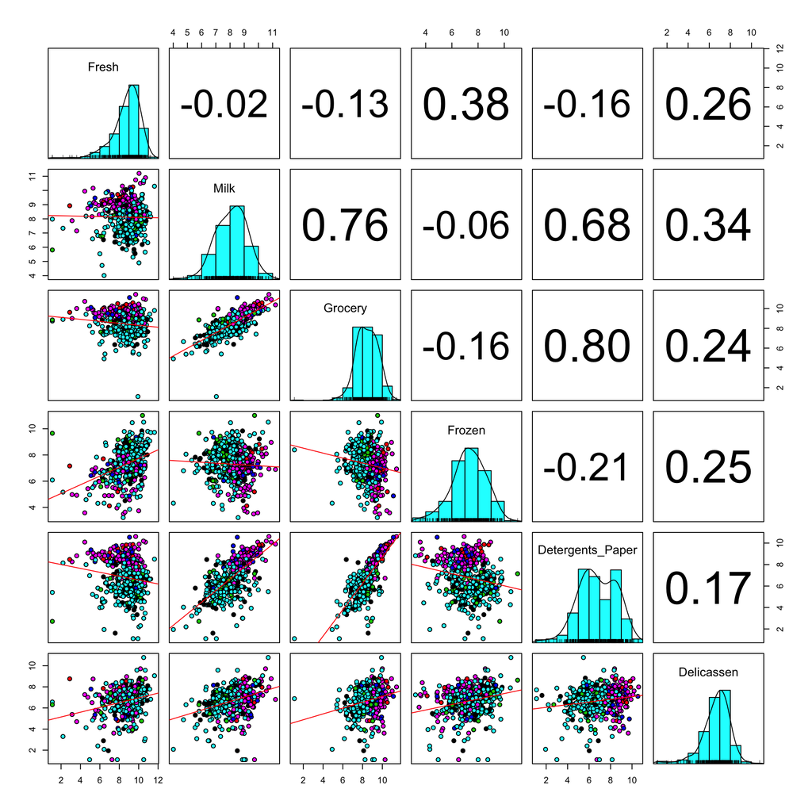

```r
pairs.panels(sales.data.log[,nums],
               bg=factor.colors[sales.data.log$ChannelAndRegion],
               pch=21,
               lm=TRUE,
               lwd = 1,
               ellipses = FALSE)
```

Уберем аутлайер, который видно в строке с Grocery.

```r
row <- which.min(sales.data.log[,"Grocery"])
sales.data.log <- sales.data.log[-row,]
```

## Проверка модели

Проверим нормальность.

```r
mshapiro.test(t(as.matrix(sales.data.log[,nums])))
```

```
##
##  Shapiro-Wilk normality test
##
## data:  Z
## W = 0.88598, p-value < 2.2e-16
```

Гипотеза о номальости отвергается.

Проверим равенство ковариационных матриц.

```r
boxM(sales.data.log[,nums], sales.data.log$ChannelAndRegion)
```

```
##
##  Box's M-test for Homogeneity of Covariance Matrices
##
## data:  sales.data.log[, nums]
## Chi-Sq (approx.) = 319.99, df = 105, p-value < 2.2e-16
```

Гипотеза о равенсвте ковариационных матриц отвергается.

# Значимость различия групп

Wilks’ Lambda Test:

```r
sales.manova <- manova(as.matrix(sales.data.log[,nums]) ~ ChannelAndRegion , data = sales.data.log)
summary(sales.manova, test = "Wilks")
```

```
##                   Df   Wilks approx F num Df den Df    Pr(>F)
## ChannelAndRegion   5 0.39363   14.997     30   1714 < 2.2e-16 ***
## Residuals        433
## ---
## Signif. codes:  0 '***' 0.001 '**' 0.01 '*' 0.05 '.' 0.1 ' ' 1
```

Различие между группами значимо. (Все это верно в нормальной модели, которой здесь нет.)

Pooled Covarience Matrix

```r
cov.list <- lapply(levels(sales.data.log$ChannelAndRegion), function(group){
 (nrow(sales.data.log[sales.data.log$ChannelAndRegion == group,nums]) - 1) * cov(sales.data.log[sales.data.log$ChannelAndRegion == group,nums])
})
cov.pooled <- Reduce("+",cov.list)/(nrow(sales.data.log) - length(levels(sales.data.log$ChannelAndRegion)))
```

Расстояние Махаланобиса между группами (Hotelling T2 test).

```r
mach <- pairwise.mahalanobis(sales.data.log[,nums], grouping = sales.data.log$ChannelAndRegion, cov = cov.pooled)
print(mach)
```

```
## $means
##            1        2        3        4        5        6
## 1.1 9.001382 7.756570 7.961288 7.573781 6.057642 6.556345
## 2.1 7.902661 9.124783 9.656924 7.271975 8.726458 7.194342
## 1.2 8.700916 7.431286 8.190612 7.819395 5.784568 6.652988
## 2.2 8.305092 8.837793 9.457913 6.864545 8.665397 6.638330
## 1.3 8.896088 7.709915 7.922872 7.458495 5.931266 6.528948
## 2.3 8.462722 9.040616 9.491755 6.769726 8.553101 6.913929
##
## $cov
##                        Fresh      Milk      Grocery       Frozen
## Fresh             2.14050968 0.1235884 -0.014162411  0.671802816
## Milk              0.12358843 0.7825135  0.454890227  0.126308889
## Grocery          -0.01416241 0.4548902  0.598416920  0.001437061
## Frozen            0.67180282 0.1263089  0.001437061  1.553779056
## Detergents_Paper -0.07665753 0.4795283  0.543787961 -0.067978106
## Delicassen        0.55015096 0.3762369  0.222884279  0.481325520
##                  Detergents_Paper Delicassen
## Fresh                 -0.07665753  0.5501510
## Milk                   0.47952833  0.3762369
## Grocery                0.54378796  0.2228843
## Frozen                -0.06797811  0.4813255
## Detergents_Paper       1.36805416  0.1690879
## Delicassen             0.16908785  1.7046792
##
## $distance
##           [,1]      [,2]      [,3]      [,4]      [,5]      [,6]
## [1,] 0.0000000 6.7703842 1.0105616 5.8524515 0.0244341 5.6786027
## [2,] 6.7703842 0.0000000 7.4268749 0.5362603 7.1439997 0.5766334
## [3,] 1.0105616 7.4268749 0.0000000 6.9662658 0.9662989 7.0933574
## [4,] 5.8524515 0.5362603 6.9662658 0.0000000 6.2212546 0.1630954
## [5,] 0.0244341 7.1439997 0.9662989 6.2212546 0.0000000 6.0067245
## [6,] 5.6786027 0.5766334 7.0933574 0.1630954 6.0067245 0.0000000
```

P-values (F distr.):

```r
num.of.groups <- length(levels(sales.data.log$ChannelAndRegion))
p.vals <- matrix(0, nrow = num.of.groups, ncol = num.of.groups)
rownames(p.vals) <- levels(sales.data.log$ChannelAndRegion)
colnames(p.vals) <- levels(sales.data.log$ChannelAndRegion)

for(i in 1:num.of.groups){
  for(j in i:num.of.groups){
    n1 <- nrow(sales.data.log[sales.data.log$ChannelAndRegion == levels(sales.data.log$ChannelAndRegion)[i],])
    n2 <- nrow(sales.data.log[sales.data.log$ChannelAndRegion == levels(sales.data.log$ChannelAndRegion)[j],])
    m <-  n1 + n2
    p <- length(nums)
    scaler <- 1/(1/n1 + 1/n2)  * (m - p + 1)/(m*p)
    p.vals[i,j] <-  1 - pf(scaler * mach$distance[i,j], p, m - p + 1)
    p.vals[j,i] <- p.vals[i,j]
  }
}

print(p.vals, digits = 3)
```

```
##          1.1      2.1      1.2      2.2      1.3   2.3
## 1.1 1.00e+00 8.45e-11 1.03e-02 5.17e-10 9.81e-01 0.000
## 2.1 8.45e-11 1.00e+00 8.91e-08 6.41e-01 0.00e+00 0.214
## 1.2 1.03e-02 8.91e-08 1.00e+00 1.09e-07 9.98e-04 0.000
## 2.2 5.17e-10 6.41e-01 1.09e-07 1.00e+00 1.11e-16 0.865
## 1.3 9.81e-01 0.00e+00 9.98e-04 1.11e-16 1.00e+00 0.000
## 2.3 0.00e+00 2.14e-01 0.00e+00 8.65e-01 0.00e+00 1.000
```

# Избыточность признаков

Какие признаки стоит рассматривать?

Выберем признаки, которые влияют на качество разделения. Forward Greedy Wilks (Stepwise Analysis):

```r
greedy.wilks(ChannelAndRegion ~ ., data = sales.data.log, niveau = 0.99)
```

```
## Formula containing included variables:
##
## ChannelAndRegion ~ Detergents_Paper + Grocery + Frozen + Milk +
##     Fresh + Delicassen
## <environment: 0x7fbb057834a8>
##
##
## Values calculated in each step of the selection procedure:
##
##               vars Wilks.lambda F.statistics.overall p.value.overall
## 1 Detergents_Paper    0.4672188             98.75215    2.672312e-69
## 2          Grocery    0.4294177             45.44806    1.074592e-72
## 3           Frozen    0.4161127             29.66375    1.075054e-71
## 4             Milk    0.4009862             22.63579    1.649004e-71
## 5            Fresh    0.3950863             18.12144    1.476601e-69
## 6       Delicassen    0.3936336             14.99677    7.957805e-67
##   F.statistics.diff p.value.diff
## 1        98.7521453 2.672312e-69
## 2         7.6056684 7.285681e-07
## 3         2.7562053 1.826610e-02
## 4         3.2442059 6.906001e-03
## 5         1.2812710 2.708705e-01
## 6         0.3159089 9.033998e-01
```

Процедура говорит, что достаточно рассматривать 4 признака: Detergents_Paper, Milk, Grocery, Frozen. Дальше гипотеза о том, что признак не влияет на результат, не отвергается.

```r
nums <- c("Detergents_Paper","Milk","Grocery","Frozen")
```

Посмотрим, что изменилось.

Wilks’ Lambda

```r
sales.manova <- manova(cbind(Detergents_Paper,Milk,Grocery,Frozen) ~ ChannelAndRegion , data = sales.data.log[,c(nums,"ChannelAndRegion")])
summary(sales.manova, test = "Wilks")
```

```
##                   Df   Wilks approx F num Df den Df    Pr(>F)
## ChannelAndRegion   5 0.40099   22.636     20 1427.1 < 2.2e-16 ***
## Residuals        433
## ---
## Signif. codes:  0 '***' 0.001 '**' 0.01 '*' 0.05 '.' 0.1 ' ' 1
```

Статистика увеличилась (0.40099 vs. 0.39363), значимость не изменилась.

# Canonical Discriminant Analysis

```r
sales.candisc <- candisc(sales.manova, data = sales.data.log)
summary(sales.candisc)
```

```
##
## Canonical Discriminant Analysis for ChannelAndRegion:
##
##      CanRsq Eigenvalue Difference  Percent Cumulative
## 1 0.5719893  1.3363900     1.2795 95.23885     95.239
## 2 0.0538543  0.0569197     1.2795  4.05643     99.295
## 3 0.0062648  0.0063043     1.2795  0.44928     99.745
## 4 0.0035717  0.0035845     1.2795  0.25545    100.000
##
## Class means:
##
##         Can1      Can2      Can3       Can4
## 1.1 -0.72931 -0.081532 -0.105203 -0.0201899
## 2.1  1.74842  0.241955 -0.288268  0.0973697
## 1.2 -0.84705  0.859565  0.065159  0.0145131
## 2.2  1.65551  0.124384 -0.031394 -0.2570719
## 1.3 -0.80441 -0.093478  0.018759  0.0037835
## 2.3  1.64520 -0.060434  0.059319  0.0297334
##
##  std coefficients:
## Detergents_Paper             Milk          Grocery           Frozen
##         0.652352         0.092913         0.363814        -0.198508
```

```r
sales.candisc$coeffs.std
```

```
##                         Can1       Can2       Can3        Can4
## Detergents_Paper  0.65235239 -0.3473904 -0.5134730 -0.88497060
## Milk              0.09291348 -1.0547837 -0.2101163  0.83341046
## Grocery           0.36381411  1.3018139  0.5009860  0.39633940
## Frozen           -0.19850775  0.4375039 -0.8896417  0.08656929
```

Первую каноническую переменную можно проинтерпретировать как продажи бытовой химии и бакалеи (больше – “лучше”). По этому признаку группы отличаются сильнее всего.

Вторую каноническую переменную можно проинтерпретировать как продажи остальных продуктов.

Можно посмотреть на pooled корреляции старых признаков и канонических переменных. Factor Structure:

```r
sales.candisc$structure
```

```
##                        Can1        Can2       Can3       Can4
## Detergents_Paper  0.9646872 -0.05217779 -0.1839563 -0.1811525
## Milk              0.7638043 -0.25109951 -0.1770311  0.5676372
## Grocery           0.9058400  0.29258336  0.0373756  0.3040590
## Frozen           -0.3210138  0.33200387 -0.8601878  0.2163342
```

# Значимое число дискриминантных функций

Lambda Prime Test

```r
print(sales.candisc)
```

```
##
## Canonical Discriminant Analysis for ChannelAndRegion:
##
##      CanRsq Eigenvalue Difference  Percent Cumulative
## 1 0.5719893  1.3363900     1.2795 95.23885     95.239
## 2 0.0538543  0.0569197     1.2795  4.05643     99.295
## 3 0.0062648  0.0063043     1.2795  0.44928     99.745
## 4 0.0035717  0.0035845     1.2795  0.25545    100.000
##
## Test of H0: The canonical correlations in the
## current row and all that follow are zero
##
##   LR test stat approx F numDF  denDF   Pr(> F)
## 1      0.40099  22.6358    20 1427.1 < 2.2e-16 ***
## 2      0.93686   2.3722    12 1140.6  0.005101 **
## 3      0.99019   0.7119     6  864.0  0.640127
## 4      0.99643              2
## ---
## Signif. codes:  0 '***' 0.001 '**' 0.01 '*' 0.05 '.' 0.1 ' ' 1
```

Процедура говорит, что достаточно взять две первые канонические переменные.

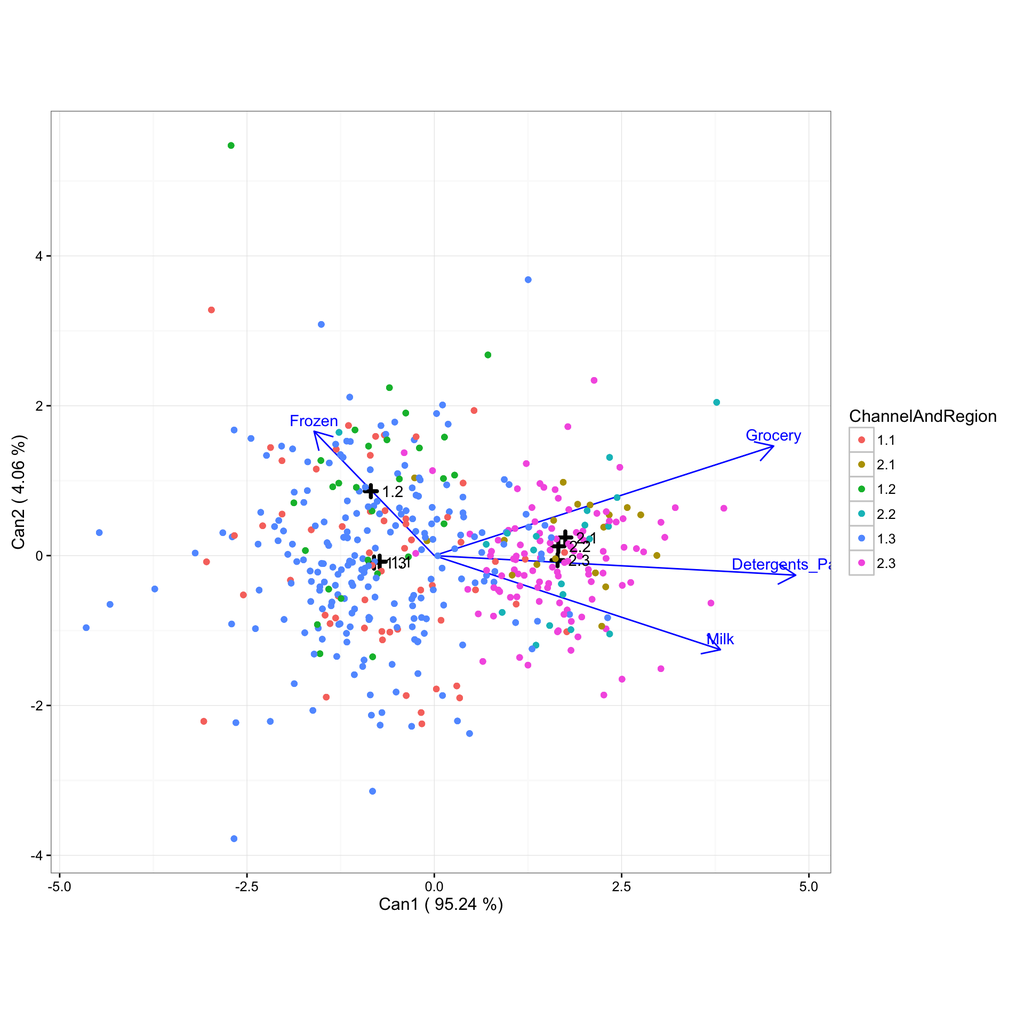

```r
candisc.object <- sales.candisc
#Nicer theme
theme_set(theme_bw())



#Basic score plot
labels <- names(candisc.object$scores)[1]
can.plot <- qplot(data=candisc.object$scores,
                   x=Can1,
                   y=Can2,
                   colour= ChannelAndRegion) +
   labs(x = paste("Can1 (", round(candisc.object$pct[1], 2), "%)"), y = paste("Can2 (", round(candisc.object$pct[2], 2), "%)")) +
  scale_size(range = c(10))+
  coord_equal()



#Add arrows

#Create arrow coordinates
arrow.coord <- data.frame(x=0,y=0,
                          xend=candisc.object$structure[,1],yend=candisc.object$structure[,2],
                          variable=row.names(candisc.object$structure))

#Enlarge arrows
enlarge <- 5
arrow.coord$xend <- enlarge*arrow.coord$xend
arrow.coord$yend <- enlarge*arrow.coord$yend


#Plot arrows
can.plot <- can.plot+geom_segment(data=arrow.coord,
                                    colour=I("blue"),
                                    aes(x=x,
                                        y=y,
                                        xend=xend,
                                        yend=yend),
                                    arrow = arrow(length = unit(0.5,"cm")))

#Add arrow labels
can.plot <- can.plot+geom_text(data=arrow.coord,
                                 colour=I("blue"),
                                 aes(x=xend,
                                     y=yend,
                                     label=variable,
                                     vjust=-0.5))

newLabs <- rownames(candisc.object$means)

can.plot <- can.plot+
  geom_point()+
  geom_point(data = candisc.object$means,
             aes( x = Can1, y = Can2),
             shape = 3,
             stroke = 2,
             colour=I("black"))

can.plot <- can.plot+
  geom_point()+
  geom_text(data = candisc.object$means,
            aes( x = Can1, y = Can2, label = newLabs),
            hjust=-0.5,
            colour=I("black"))

print(can.plot)
```

Группы:

- 1.1 – годовые продажи различной продукции в Лиссабоне отелям и ресторанам
- 1.2 – годовые продажи различной продукции в Порту отелям и ресторанам
- 1.3 – годовые продажи различной продукции в других регионах отелям и ресторанам
- 2.1 – годовые продажи различной продукции в Лиссабоне розничным сетям
- 2.2 – годовые продажи различной продукции в Порту розничным сетям
- 2.3 – годовые продажи различной продукции в других регионах розничным сетям

Смотрим на центры групп.

### Интерпретация по факторной структуре

Справа находятся те, что имеют бОльшие значения всего кроме Frozen.

По первой канонической переменной различаются розница и отели/рестораны. Видно, что в отелях и ресторанах больше употребляются замороженные продукты.

Сверху находятся те, что имеют бОльшие значения бакалеи и замороженных продуктов.

По второй канонической переменной отличаются Порту и остальные регионы. В Порту в отелях и ресторанах закупается больше бакалеи и замороженных продуктов чем в остальных городах.

### Интерпретация по стандартизованным каноническим коэффициентам

Если интерпретировать по стандартизованным каноническим коэффициентам, получается примерно то же самое.

Справа должны оказаться те, у кого наибольшие значения химии и бакалеи, но маленькие по замороженной продукции; молоко роли почти не играет (в этом отличие от интерпретации по факторной структуре).

По второй канонической переменной сверху должны оказаться те, у кого большие значения бакалеи и замороженных продуктов, но маленькие значения молока. Здесь химиия почти не учитывается.

Различия групп интерпретируются так же.

# Классификация (по двум группам)

## LDA

```r
sales.train <- sales.data.log.ch
sales.lda <- lda(sales.train[,nums], sales.train$Channel)
sales.lda
```

```
## Call:
## lda(sales.train[, nums], sales.train$Channel)
##
## Prior probabilities of groups:
##         1         2
## 0.6772727 0.3227273
##
## Group means:
##   Detergents_Paper     Milk  Grocery   Frozen
## 1         5.926286 7.690711 7.932735 7.518359
## 2         8.590101 9.024146 9.508164 6.846079
##
## Coefficients of linear discriminants:
##                         LD1
## Detergents_Paper  0.5802894
## Milk              0.2048498
## Grocery           0.2955470
## Frozen           -0.1672538
```

Plug-in classification table

```r
sales.lda.predict <- predict(sales.lda, sales.train[,nums])$class
table(sales.lda.predict, sales.train$Channel) #Качество классификации
```

```
##
## sales.lda.predict   1   2
##                 1 275  12
##                 2  23 130
```

Доля ошибок

```r
ct <- table(sales.lda.predict, sales.train$Channel)
1 - diag(prop.table(ct, 1))
```

```
##          1          2
## 0.04181185 0.15032680
```

Cross-validation table

```r
sales.lda <- lda(sales.train[,nums], sales.train$Channel, CV = TRUE)
table(sales.lda$class, sales.train$Channel) #cross-validation
```

```
##
##       1   2
##   1 275  12
##   2  23 130
```

Доля ошибок

```r
ct <- table(sales.lda$class, sales.train$Channel)
1 - diag(prop.table(ct, 1))
```

```
##          1          2
## 0.04181185 0.15032680
```

Не хуже чем без cross validation.

Out-of-sample

```r
sales.train <- sales.data.log.ch[seq(1,nrow(sales.data.log.ch),2),]
sales.unknown <- sales.data.log.ch[-seq(1,nrow(sales.data.log.ch),2),]
```

```r
sales.lda <- lda(sales.train[,nums], sales.train$Channel)
sales.lda
```

```
## Call:
## lda(sales.train[, nums], sales.train$Channel)
##
## Prior probabilities of groups:
##         1         2
## 0.7090909 0.2909091
##
## Group means:
##   Detergents_Paper     Milk  Grocery   Frozen
## 1         5.914530 7.636639 7.956725 7.447197
## 2         8.444315 8.896479 9.345531 6.800977
##
## Coefficients of linear discriminants:
##                          LD1
## Detergents_Paper  0.56938871
## Milk             -0.01444629
## Grocery           0.61273234
## Frozen           -0.12489207
```

Plug-in classification table

```r
sales.lda.predict <- predict(sales.lda, sales.unknown[,nums])$class
table(sales.lda.predict, sales.unknown$Channel) #Качество классификации
```

```
##
## sales.lda.predict   1   2
##                 1 129   7
##                 2  13  71
```

Доля ошибок

```r
ct <- table(sales.lda.predict, sales.unknown$Channel)
1 - diag(prop.table(ct, 1))
```

```
##          1          2
## 0.05147059 0.15476190
```

Чуть хуже чем без тестовой выборки.

Попарный дискриминантный анализ.

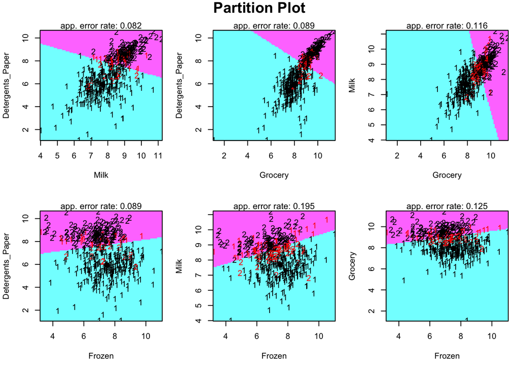

```r
partimat(Channel ~ ., sales.data.log.ch[,c(nums, "Channel")], method="lda")
```

## QDA

```r
sales.train <- sales.data.log.ch
sales.qda <- qda(sales.train[,nums], sales.train$Channel)
sales.qda
```

```
## Call:
## qda(sales.train[, nums], sales.train$Channel)
##
## Prior probabilities of groups:
##         1         2
## 0.6772727 0.3227273
##
## Group means:
##   Detergents_Paper     Milk  Grocery   Frozen
## 1         5.926286 7.690711 7.932735 7.518359
## 2         8.590101 9.024146 9.508164 6.846079
```

Plug-in classification table

```r
sales.qda.predict <- predict(sales.qda, sales.train[,nums])$class
table(sales.qda.predict, sales.train$Channel) #Качество классификации
```

```
##
## sales.qda.predict   1   2
##                 1 269  11
##                 2  29 131
```

Доля ошибок

```r
ct <- table(sales.qda.predict, sales.train$Channel)
1 - diag(prop.table(ct, 1))
```

```
##          1          2
## 0.03928571 0.18125000
```

Хуже чем в lda.

Cross-validation table

```r
sales.qda <- qda(sales.train[,nums], sales.train$Channel, CV = TRUE)
table(sales.qda$class, sales.train$Channel) #cross-validation
```

```
##
##       1   2
##   1 269  13
##   2  29 129
```

Доля ошибок

```r
ct <- table(sales.qda$class, sales.train$Channel)
1 - diag(prop.table(ct, 1))
```

```
##          1          2
## 0.04609929 0.18354430
```

Чуть хуже чем без cross validation.

Out-of-sample

```r
sales.train <- sales.data.log.ch[seq(1,nrow(sales.data.log.ch),2),]
sales.unknown <- sales.data.log.ch[-seq(1,nrow(sales.data.log.ch),2),]
```

```r
sales.qda <- qda(sales.train[,nums], sales.train$Channel)
sales.qda
```

```
## Call:
## qda(sales.train[, nums], sales.train$Channel)
##
## Prior probabilities of groups:
##         1         2
## 0.7090909 0.2909091
##
## Group means:
##   Detergents_Paper     Milk  Grocery   Frozen
## 1         5.914530 7.636639 7.956725 7.447197
## 2         8.444315 8.896479 9.345531 6.800977
```

Plug-in classification table

```r
sales.qda.predict <- predict(sales.qda, sales.unknown[,nums])$class
table(sales.qda.predict, sales.unknown$Channel) #Качество классификации
```

```
##
## sales.qda.predict   1   2
##                 1 127  10
##                 2  15  68
```

Доля ошибок

```r
ct <- table(sales.qda.predict, sales.unknown$Channel)
1 - diag(prop.table(ct, 1))
```

```
##         1         2
## 0.0729927 0.1807229
```

Хуже чем без тестовой выборки.

Попарный qda.

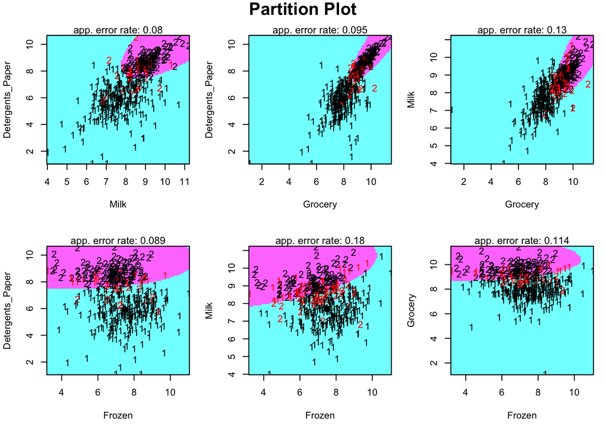

```r
partimat(Channel ~ ., sales.data.log.ch[,c(nums, "Channel")], method="qda")
```

## Вывод

Классификация по qda уступает классификации по lda. Если хотим классифицировать новые данные, то имеет смысл делать это по lda.